# E-news Express Project

### 4. Does the converted status depend on the preferred language?

```python
# creating a contingency table
language_contingency_table = pd.crosstab(df.converted,df.language_preferred)
language_contingency_table
```

| language_preferred converted | English | French | Spanish |
| --- | --- | --- | --- |
| no | 11 | 19 | 16 |
| yes | 21 | 15 | 18 |

#### Visual Analysis

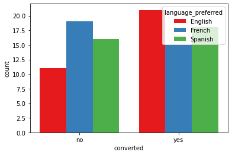

```python
sns.countplot(x="converted", hue="language_preferred", data=df, palette='Set1',saturation=50);
```

#### Observation

##### Significance of the Test

In the contingency table, H0: The row and column variables are independent.

##### Assumptions

1. Categorical Variables.
2. Expected value of the number of observations in each level of the variable is at least 5.
3. Random sampling from the population.

##### Test Statistic Distribution

#### Chi-square test of Independence.

#### Lets write the null and alternative hypothesis

We will test the null hypothesis.

> $H_0: Converted status is independent preferred language

against the alternative hypothesis

> $H_a: Converted status depends on preferred language

##### Lets find the p_value

```python
from scipy.stats import chi2_contingency

chi, p_value, dof, expected = chi2_contingency(language_contingency_table)
p_value
```

```
0.21298887487543447
```

#### Insight

```python
print(df.groupby('language_preferred')['time_spent_on_the_page'].mean())
```

```
language_preferred
English    5.559063
French     5.253235
Spanish    5.331765
Name: time_spent_on_the_page, dtype: float64
```

### 5. Is mean time spent on the new page same for the different language users.

```python
df['language_preferred'].value_counts()
```

```
French     34
Spanish    34
English    32
Name: language_preferred, dtype: int64
```

Here, 'time_spent_on_the_new_page' is dependent variable which is continuous and assumed to follow normal distribution. 'language_preferred' is independent exploratory variable with several levels.

##### Significance of the Test

> $H_0: Mean time spent on the new page is same for different language users.

against the alternative hypothesis

> $H_a: Mean time spent on the new page is different for different language users.

##### Assumptions

1. The population are normally distributed.
2. Samples are independent simple random samples.

##### Test Statistic Distribution

#### One-way ANOVA F-test

```python
df.head()
```

| user_id | group | landing_page | time_spent_on_the_page | converted | language_preferred |
| --- | --- | --- | --- | --- | --- |
| 546592 | control | old | 3.48 | no | Spanish |
| 546468 | treatment | new | 7.13 | yes | English |
| 546462 | treatment | new | 4.40 | no | Spanish |
| 546567 | control | old | 3.02 | no | French |
| 546459 | treatment | new | 4.75 | yes | Spanish |

```python
print(df[df.landing_page=="new"].groupby('language_preferred')['time_spent_on_the_page'].mean())
```

```
language_preferred
English    6.663750
French     6.196471
Spanish    5.835294
Name: time_spent_on_the_page, dtype: float64
```

#### Visual Analysis

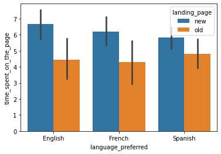

```python
sns.barplot(x="language_preferred",y="time_spent_on_the_page", data =df, hue="landing_page")
```

#### Observation

1. Among the users who prefer English, French and Spanish, the users prefer to use new_landing_page.
2. The time spent on the new landing page is more than old landing page irrespective of the language preferred.

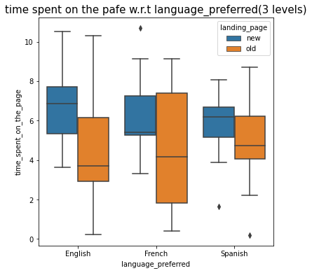

```python
fig, ax = plt.subplots(figsize = (6,6))
a = sns.boxplot(x = 'language_preferred', y = 'time_spent_on_the_page', data = df, hue = 'landing_page')
a.set_title("time spent on the pafe w.r.t language_preferred(3 levels)", fontsize = 15)
plt.show()
```

Now, the normality and equility of variance assumptions need to be checked.

1. For testing Normality - Shapiro-Wilk's test
2. For Equality of Variance, Levene Test

#### Shapiro- Wilk's test

We will test the null hypothesis

> $H_0: time_spent_on_the_page follow normal distribution

against the alternative hypothesis

> $H_a: time_spent_on_the_page doesnot follow normal distribution

```python
from scipy import stats

w, p_value = stats.shapiro(df[df.landing_page=="new"]['time_spent_on_the_page'])
p_value
```

```
0.8040016293525696
```

Since, p_valus is larger than 0.05 we fail to reject the null hypothesis follow normal distribution.

```python
#### Levene's test

from scipy.stats import levene

statistic, p_value = levene(df[df.landing_page=="new"]['time_spent_on_the_page'][df['language_preferred']== 'English'], df[df.landing_page=="new"]['time_spent_on_the_page'][df['language_preferred']== 'French'],df[df.landing_page=="new"]['time_spent_on_the_page'][df['language_preferred']== 'Spanish'])
p_value
```

```
0.46711357711340173
```

#### Lets test whether the assumptions are satisfied or not.

1. The population are normally distributed - yes, normal distribution is verified using Shapiro-Wilk's test
2. Samples are independent simple random variables - yes, we are informed that the collected sample is a simple random sample.
3. Population variances are equal - Yes, the homogeneity of variance assumption is verified using the Levene's test.

### Finding p_value

```python
from scipy.stats import f_oneway

df_new = df[df.landing_page=="new"]
test_stat, p_value = f_oneway(df_new.loc[df_new['language_preferred'] == 'English','time_spent_on_the_page'],df_new.loc[df_new['language_preferred'] == 'French','time_spent_on_the_page'], df_new.loc[df_new['language_preferred'] == 'Spanish','time_spent_on_the_page'])

p_value
```

```
0.43204138694325955
```

The p_value is much larger than 0.05. Hence, we fail to reject the hypothesis. Hence, Mean time spent on the new page is same for different language users.

```python
from statsmodels.stats.multicomp import pairwise_tukeyhsd

m_comp = pairwise_tukeyhsd(endog = df_new['time_spent_on_the_page'], groups = df_new['language_preferred'], alpha = 0.05)
print(m_comp)
```

```
 Multiple Comparison of Means - Tukey HSD, FWER=0.05
=====================================================
 group1  group2 meandiff p-adj   lower  upper  reject
-----------------------------------------------------
English  French  -0.4673 0.7259 -2.0035  1.069  False
English Spanish  -0.8285  0.401 -2.3647 0.7078  False
 French Spanish  -0.3612  0.816  -1.874 1.1516  False
-----------------------------------------------------
```

From the above pairwise comparison, looking at the reject column we can say that the mean_time_spent_on_the_new_page is not so different between (English and French), (English and Spanish) and (French and Spanish)

### Conclusions and Recommendations

Analyzed the data of nearly 100 users who use the online news portal. A new feature has been added to the portal. The main focus is the time spent on the page.

From Hypothesis test,

1. We have statistical evidence that that time spent on new landing page is more than time spent on old landing page.
2. Conversion rate for the new page greater than the conversion rate for the old page.
3. Converted status is independent of the language_preferred
4. The mean_time_spent_on_the_new_page is not so different between (English and French), (English and Spanish) and (French and Spanish) From both visual and hypothesis test, we observe that the new feature seems to attract more users.